# Supporting Information: ‘Sex differences in allometry for phenotypic traits in mice indicate that females are not scaled males’

## Extra: dataset for comparing models with and wihout substrains

```r
short_list <- discard(dat_list, ~.x[["nstrain"]][[1]] == 1)

processing2 <- map_dfr(short_list, get_para_poss2)
dat_short <- data.frame(processing2, row.names = NULL)

dat_short %>%
    left_join(dat_category, by = ("parameter_name" = "parameter_name")) %>%
    arrange(Category) -> dat_short

dim(dat_short)

# write_csv(dat, here('data/test4.csv'))
write_csv(dat_short, here("data/data_comparision.csv"))
```

# Data analysis

## Preparation for categorizing into scenarios

Here, we merge p values for non-independent (closely related traits) using the custom functions for merging p values via the `poolr` package.

```r
# here we need to collapse p values which are related split data into 2 ones
# with replications within parameter_group

dat %>%
    group_by(parameter_group) %>%
    mutate(count = n()) -> dat
#
dat1 <- dat[which(dat$count == 1), ]
# dim(dat1)

# taking out independent traits
dat2 <- dat[-which(dat$count == 1), ]

# nesting data into a lot of data sets and apply p_mod function
n_dat2 <- dat2 %>%
    group_by(parameter_group) %>%
    nest()

# function to get merged p value for intercepts
p_mod_int <- function(data) {

    len <- dim(data)[1]
    Rmat <- matrix(0.8, nrow = len, ncol = len)
    diag(Rmat) <- 1

    p_mod <- fisher(data$fm_diff_int_p, adjust = "liji", R = Rmat)
    p <- p_mod$p
    return(p)

}


# function to get merged p value for slopes
p_mod_slp <- function(data) {

    len <- dim(data)[1]
    Rmat <- matrix(0.8, nrow = len, ncol = len)
    diag(Rmat) <- 1

    p_mod <- fisher(data$fm_diff_slope_p, adjust = "liji", R = Rmat)
    p <- p_mod$p
    return(p)

}

# function to get merged p value for SD
p_mod_sd <- function(data) {

    len <- dim(data)[1]
    Rmat <- matrix(0.8, nrow = len, ncol = len)
    diag(Rmat) <- 1

    p_mod <- fisher(data$p_val_sd, adjust = "liji", R = Rmat)
    p <- p_mod$p
    return(p)

}


# merged dat2
m_dat2 <- n_dat2 %>%
    mutate(merged_p_sd = map_dbl(data, p_mod_sd), merged_p_int = map_dbl(data, p_mod_int),
        merged_p_slp = map_dbl(data, p_mod_slp))
```

## The number of cases Scenario A

```r
# full dataset
dat_slopes <- dat %>%
    filter(fm_diff_slope_p <= 0.05 & fm_diff_int_p > 0.05)

# 17 out of 363 traits sig slope diff - scenario A
nrow(dat_slopes)
```

```
## [1] 17
```

```r
# reduced dataset
dat_slopes1 <- dat1 %>%
    filter(fm_diff_slope_p <= 0.05 & fm_diff_int_p > 0.05)

dat_slopes2 <- m_dat2 %>%
    filter(merged_p_slp <= 0.05 & merged_p_int > 0.05)

# 11 out of 219 traits sig slope diff - scenario A
nrow(dat_slopes1) + nrow(dat_slopes2)
```

```
## [1] 11
```

## The number of Scenario B

```r
# full dataset
dat_int <- dat %>%
    filter(fm_diff_int_p <= 0.05 & fm_diff_slope_p > 0.05)

# 154 out of 363 traits sig intercept diff same slope - scenario B
nrow(dat_int)
```

```
## [1] 154
```

```r
# reduced dataset
dat_int1 <- dat1 %>%
    filter(fm_diff_int_p <= 0.05 & fm_diff_slope_p > 0.05)

dat_int2 <- m_dat2 %>%
    filter(merged_p_int <= 0.05 & merged_p_slp > 0.05)

# 93 out of 219 traits sig intercept diff same slope - scenario B
nrow(dat_int1) + nrow(dat_int2)
```

```
## [1] 93
```

## The number of Scenario C

```r
# full dataset
dat_intSlopes <- dat %>%
    filter(fm_diff_int_p <= 0.05 & fm_diff_slope_p <= 0.05)

# 70 out of 363 sig intercept and slope diff - scenario C
nrow(dat_intSlopes)
```

```
## [1] 70
```

```r
# reduced dataset
dat_intSlopes1 <- dat1 %>%
    filter(fm_diff_int_p <= 0.05 & fm_diff_slope_p <= 0.05)

dat_intSlopes2 <- m_dat2 %>%
    filter(merged_p_int <= 0.05 & merged_p_slp <= 0.05)

# 57 out of 219 sig intercept and slope diff - scenario C
nrow(dat_intSlopes1) + nrow(dat_intSlopes2)
```

```
## [1] 57
```

## Not in these scenarios

```r
# full dataset
dat_intslopesNS <- dat %>%
    filter(fm_diff_slope_p > 0.05 & fm_diff_int_p > 0.05)
# 122 out of 363 - no sig difference between intercept and slope - scenario D
nrow(dat_intslopesNS)
```

```
## [1] 122
```

```r
# reduced dataset
dat_intslopesNS1 <- dat1 %>%
    filter(fm_diff_slope_p > 0.05 & fm_diff_int_p > 0.05)

dat_intslopesNS2 <- m_dat2 %>%
    filter(merged_p_int > 0.05 & merged_p_slp > 0.05)

# 58 out of 219 no sig difference between intercept and slope - scenario D
nrow(dat_intslopesNS1) + nrow(dat_intslopesNS2)
```

```
## [1] 58
```

## Sex difference in residual SD

```r
# full dataset 249 out of 363 signficant differences in residual SDs
length(which(dat$p_val_sd <= 0.05))
```

```
## [1] 249
```

```r
# hist(log(dat$p_val_sd)) # p = 0.05 ~ - 3

# 154 of out of 219 signficant differences in residual SDs
length(which(m_dat2$merged_p_sd <= 0.05)) + length(which(dat1$p_val_sd <= 0.05))
```

```
## [1] 154
```

## Creating Figure 2

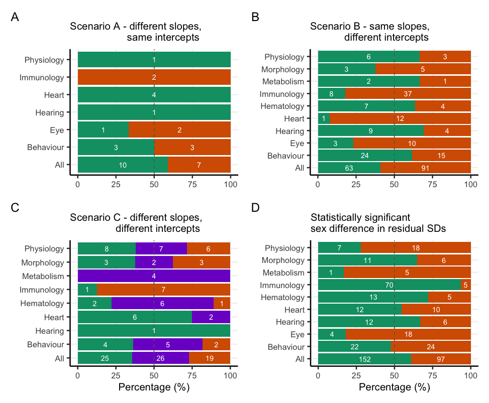

```r
# set colour for males and females

colours <- c("#D55E00", "#009E73")  # c('#882255','#E69F00')
colours2 <- c("#D55E00", "#7D26CD", "#009E73")

# sex bias in slope parameter under scenario A
dat_p1 <- dat_slopes %>%
    group_by_at(vars(Category)) %>%
    summarise(malebias = sum(m_slope > f_slope), femalebias = sum(f_slope > m_slope),
        total = malebias + femalebias, malepercent = malebias * 100/total, femalepercent = femalebias *
            100/total)


dat_p1 <- gather(as.data.frame(dat_p1), key = sex, value = percent, malepercent:femalepercent,
    factor_key = TRUE)


dat_p1$samplesize <- with(dat_p1, ifelse(sex == "malepercent", malebias, femalebias))

# Adding All
dat_p1 %>%
    group_by(sex) %>%
    summarise(malebias = sum(malebias), femalebias = sum(femalebias), total = sum(total),
        ) -> part

part %>%
    mutate(Category = "All", sex = c("malepercent", "femalepercent"), percent = c(100 *
        (malebias[1]/total[1]), 100 * (femalebias[1]/total[1])), samplesize = c(malebias[1],
        femalebias[1])) -> part


# select(Category, malebias, femalebias, total, sex, percent, samplesize)
dat_p1 <- bind_rows(dat_p1, part)



p1 <- ggplot(dat_p1) + aes(x = Category, y = percent, fill = sex) + geom_col() +
    geom_hline(yintercept = 50, linetype = "dashed", color = "gray40") + geom_text(data = subset(dat_p1,
    samplesize != 0), aes(label = samplesize), position = position_stack(vjust = 0.5),
    color = "white", size = 3.5) + scale_fill_manual(values = colours) + theme_bw(base_size = 18) +
    theme(strip.text.y = element_text(angle = 270, size = 10, margin = margin(t = 15,
        r = 15, b = 15, l = 15)), strip.text.x = element_text(size = 12), strip.background = element_rect(colour = NULL,
        linetype = "blank", fill = "gray90"), text = element_text(size = 14), panel.spacing = unit(0.5,
        "lines"), panel.border = element_blank(), axis.line = element_line(), panel.grid.major.x = element_line(linetype = "solid",
        colour = "gray95"), panel.grid.major.y = element_line(linetype = "solid",
        colour = "gray95"), panel.grid.minor.y = element_blank(), panel.grid.minor.x = element_blank(),
        axis.title.x = element_blank(), axis.title.y = element_blank(), plot.title = element_text(size = 14),
        legend.position = "none") + coord_flip() + labs(title = "Scenario A - different slopes, \n                    same intercepts")



# sex bias in intercept parameter - scenario B
dat_p2 <- dat_int %>%
    group_by_at(vars(Category)) %>%
    summarise(malebias = sum(m_intercept > f_intercept), femalebias = sum(f_intercept >
        m_intercept), total = malebias + femalebias, malepercent = malebias * 100/total,
        femalepercent = femalebias * 100/total)

dat_p2 <- gather(as.data.frame(dat_p2), key = sex, value = percent, malepercent:femalepercent,
    factor_key = TRUE)

dat_p2$samplesize <- with(dat_p2, ifelse(sex == "malepercent", malebias, femalebias))

# addeing All
dat_p2 %>%
    group_by(sex) %>%
    summarise(malebias = sum(malebias), femalebias = sum(femalebias), total = sum(total),
        ) -> part2

part2 %>%
    mutate(Category = "All", sex = c("malepercent", "femalepercent"), percent = c(100 *
        (malebias[1]/total[1]), 100 * (femalebias[1]/total[1])), samplesize = c(malebias[1],
        femalebias[1])) -> part2


# select(Category, malebias, femalebias, total, sex, percent, samplesize)
dat_p2 <- bind_rows(dat_p2, part2)


p2 <- ggplot(dat_p2) + aes(x = Category, y = percent, fill = sex) + geom_col() +
    geom_hline(yintercept = 50, linetype = "dashed", color = "gray40") + geom_text(data = subset(dat_p2,
    samplesize != 0), aes(label = samplesize), position = position_stack(vjust = 0.5),
    color = "white", size = 3.5) + scale_fill_manual(values = colours) + theme_bw(base_size = 18) +
    theme(strip.text.y = element_text(angle = 270, size = 10, margin = margin(t = 15,
        r = 15, b = 15, l = 15)), strip.text.x = element_text(size = 12), strip.background = element_rect(colour = NULL,
        linetype = "blank", fill = "gray90"), text = element_text(size = 14), panel.spacing = unit(0.5,
        "lines"), panel.border = element_blank(), axis.line = element_line(), panel.grid.major.x = element_line(linetype = "solid",
        colour = "gray95"), panel.grid.major.y = element_line(linetype = "solid",
        color = "gray95"), panel.grid.minor.y = element_blank(), panel.grid.minor.x = element_blank(),
        axis.title.x = element_blank(), axis.title.y = element_blank(), plot.title = element_text(size = 14),
        legend.position = "none") + coord_flip() + labs(title = "Scenario B - same slopes, \n            different intercepts")


# sex bias in sig intercept and slope parameter - scenario C
dat_p3 <- dat_intSlopes %>%
    group_by_at(vars(Category)) %>%
    summarise(malebias = sum(m_intercept > f_intercept & m_slope > f_slope), mixed = sum(m_intercept >
        f_intercept & m_slope < f_slope, m_intercept < f_intercept & m_slope > f_slope),
        femalebias = sum(f_intercept > m_intercept & f_slope > m_slope), total = malebias +
            mixed + femalebias, malepercent = malebias * 100/total, mixedpercent = mixed *
            100/total, femalepercent = femalebias * 100/total)

dat_p3 <- gather(as.data.frame(dat_p3), key = sex, value = percent, malepercent:femalepercent,
    factor_key = TRUE)
dat_p3$samplesize <- with(dat_p3, ifelse(sex == "malepercent", malebias, ifelse(sex ==
    "mixedpercent", mixed, femalebias)))


# adding All
dat_p3 %>%
    group_by(sex) %>%
    summarise(malebias = sum(malebias), mixed = sum(mixed), femalebias = sum(femalebias),
        total = sum(total), ) -> part3

part3 %>%
    mutate(Category = "All", sex = c("malepercent", "mixedpercent", "femalepercent"),
        percent = c(100 * (malebias[1]/total[1]), 100 * (mixed[1]/total[1]), 100 *
            (femalebias[1]/total[1])), samplesize = c(malebias[1], mixed[1], femalebias[1])) ->
    part3


# select(Category, malebias, femalebias, total, sex, percent, samplesize)
dat_p3 <- bind_rows(dat_p3, part3)

p3 <- ggplot(dat_p3) + aes(x = Category, y = percent, fill = sex) + geom_col() +
    geom_hline(yintercept = 50, linetype = "dashed", color = "gray40") + geom_text(data = subset(dat_p3,
    samplesize != 0), aes(label = samplesize), position = position_stack(vjust = 0.5),
    color = "white", size = 3.5) + scale_fill_manual(values = colours2) + theme_bw(base_size = 18) +
    theme(strip.text.y = element_text(angle = 270, size = 10, margin = margin(t = 15,
        r = 15, b = 15, l = 15)), strip.text.x = element_text(size = 12), strip.background = element_rect(colour = NULL,
        linetype = "blank", fill = "gray90"), text = element_text(size = 14), panel.spacing = unit(0.5,
        "lines"), panel.border = element_blank(), axis.line = element_line(), panel.grid.major.x = element_line(linetype = "solid",
        colour = "gray95"), panel.grid.major.y = element_line(linetype = "solid",
        color = "gray95"), panel.grid.minor.y = element_blank(), panel.grid.minor.x = element_blank(),
        axis.title.y = element_blank(), plot.title = element_text(size = 14), legend.position = "none") +
    ylab("Percentage (%)") + coord_flip() + labs(title = "Scenario C - different slopes, \n                different intercepts")

# sex bias in sd
dat_p4 <- dat %>%
    filter(p_val_sd <= 0.05) %>%
    group_by_at(vars(Category)) %>%
    summarise(malebias = sum(m_sd > f_sd), femalebias = sum(f_sd > m_sd), total = malebias +
        femalebias, malepercent = malebias * 100/total, femalepercent = femalebias *
        100/total)


dat_p4 <- gather(as.data.frame(dat_p4), key = sex, value = percent, malepercent:femalepercent,
    factor_key = TRUE)

dat_p4$samplesize <- with(dat_p4, ifelse(sex == "malepercent", malebias, femalebias))


# addeing All
dat_p4 %>%
    group_by(sex) %>%
    summarise(malebias = sum(malebias), femalebias = sum(femalebias), total = sum(total),
        ) -> part4

part4 %>%
    mutate(Category = "All", sex = c("malepercent", "femalepercent"), percent = c(100 *
        (malebias[1]/total[1]), 100 * (femalebias[1]/total[1])), samplesize = c(malebias[1],
        femalebias[1])) -> part4


# select(Category, malebias, femalebias, total, sex, percent, samplesize)
dat_p4 <- bind_rows(dat_p4, part4)

p4 <- ggplot(dat_p4) + aes(x = Category, y = percent, fill = sex) + geom_col() +
    geom_hline(yintercept = 50, linetype = "dashed", color = "gray40") + geom_text(data = subset(dat_p4,
    samplesize != 0), aes(label = samplesize), position = position_stack(vjust = 0.5),
    color = "white", size = 3.5) + scale_fill_manual(values = colours) + theme_bw(base_size = 18) +
    theme(strip.text.y = element_text(angle = 270, size = 10, margin = margin(t = 15,
        r = 15, b = 15, l = 15)), strip.text.x = element_text(size = 12), strip.background = element_rect(colour = NULL,
        linetype = "blank", fill = "gray90"), text = element_text(size = 14), panel.spacing = unit(0.5,
        "lines"), panel.border = element_blank(), axis.line = element_line(), panel.grid.major.x = element_line(linetype = "solid",
        colour = "gray95"), panel.grid.major.y = element_line(linetype = "solid",
        color = "gray95"), panel.grid.minor.y = element_blank(), panel.grid.minor.x = element_blank(),
        axis.title.y = element_blank(), plot.title = element_text(size = 14), legend.position = "none") +
    ylab("Percentage (%)") + coord_flip() + labs(title = "Statistically significant\nsex difference in residual SDs")

# putting all together
(p1 + p2)/(p3 + p4) + plot_annotation(tag_levels = "A")

# note that the key was inserted using Illustrator
```

**Fig. 2** Sex biases for mice phenotypic traits arrange in functional groups (see the main tex)

## Functional categories in the dataset

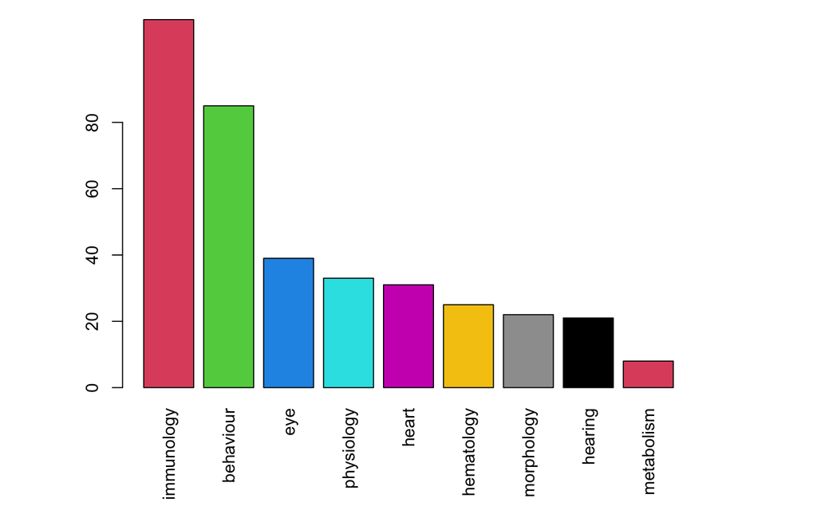

```r
par(mar = c(6, 6, 6, 6))
v = c(85, 39, 21, 31, 25, 111, 8, 22, 33)
t = c("behaviour", "eye", "hearing", "heart", "hematology", "immunology", "metabolism",
    "morphology", "physiology")
d = data.frame(trait = t, n = v)
d = d[order(d$n, decreasing = TRUE), ]
barplot(height = d$n, names.arg = d$trait, las = 3, col = seq_along(d$trait) + 1,
    ylim = c(0, 80))
```

**Fig. S1** The number of traits in each of 9 functional categories.

## Extra: Comparing models with and wihout substrains

```r
# loading data
dat_short <- read_csv(here("data/data_comparision.csv"))


dat_short %>%
    group_by(parameter_group) %>%
    mutate(count = n()) -> dat_short
#
dat_short1 <- dat_short[which(dat_short$count == 1), ]
# dim(dat1)

# taking out independent traits
dat_short2 <- dat_short[-which(dat_short$count == 1), ]

# nesting data into a lot of data sets and apply p_mod function
n_dat_short2 <- dat_short2 %>%
    group_by(parameter_group) %>%
    nest()

# function to get merged p value for comparing models
p_comp <- function(data) {

    len <- dim(data)[1]
    Rmat <- matrix(0.8, nrow = len, ncol = len)
    diag(Rmat) <- 1

    p_mod <- fisher(data$p_value, adjust = "liji", R = Rmat)
    p <- p_mod$p
    return(p)

}

# merged data
m_dat_short2 <- n_dat_short2 %>%
    mutate(merged_p_comp = map_dbl(data, p_comp))

# short dataset
dat_sig <- dat_short %>%
    filter(p_value <= 0.05)

# 155 out of 248 traits sig comparisons
nrow(dat_short)
```

```
## [1] 248
```

```r
nrow(dat_sig)
```

```
## [1] 155
```

```r
# reduced dataset
dat_sig1 <- dat_short1 %>%
    filter(p_value <= 0.05)

dat_sig2 <- m_dat_short2 %>%
    filter(merged_p_comp <= 0.05)

# 98 out of 154 traits sig comparisons
nrow(dat_short1) + nrow(m_dat_short2)
```

```
## [1] 154
```

```r
nrow(dat_sig1) + nrow(dat_sig2)
```

```
## [1] 98
```

# Meta-analysis

## Calculating absolute effect sizes

Here we convert our effect sizes to absolute values assuming folded normal distributions.

```r
## for folded normal distribution see:
## https://en.wikipedia.org/wiki/Folded_normal_distribution

# folded mean
folded_mu <- function(mean, variance) {
    mu <- mean
    sigma <- sqrt(variance)
    fold_mu <- sigma * sqrt(2/pi) * exp((-mu^2)/(2 * sigma^2)) + mu * (1 - 2 * pnorm(-mu/sigma))
    fold_mu
}

# folded variance
folded_v <- function(mean, variance) {
    mu <- mean
    sigma <- sqrt(variance)
    fold_mu <- sigma * sqrt(2/pi) * exp((-mu^2)/(2 * sigma^2)) + mu * (1 - 2 * pnorm(-mu/sigma))
    fold_se <- sqrt(mu^2 + sigma^2 - fold_mu^2)
    # adding se to make bigger mean
    fold_v <- fold_se^2
    fold_v
}


dat <- dat %>%
    mutate(abs_int = folded_mu(fm_diff_int, fm_diff_int_se^2), abs_slope = folded_mu(fm_diff_slope,
        fm_diff_slope_se^2), abs_lnVR = folded_mu(lnVR, VlnVR), V_abs_int = folded_v(fm_diff_int,
        fm_diff_int_se^2), V_abs_slope = folded_v(fm_diff_slope, fm_diff_slope_se^2),
        V_abs_lnVR = folded_v(lnVR, VlnVR), total_n = f_n + m_n)
```

## Comparing sex difference in intercepts

This is a meta-analytic model of sex differences in intercepts (mean traits). We use the `rubust` function calculates to see whether our results form the model is robust (consistent).

```r
modelia <- rma.mv(yi = abs_int, V = V_abs_int, random = list(~1 | Category, ~1 |
    parameter_group, ~1 | obs), data = dat)
summary(modelia)
```

```
##
## Multivariate Meta-Analysis Model (k = 363; method: REML)
##
##    logLik   Deviance        AIC        BIC       AICc
##  296.4722  -592.9444  -584.9444  -569.3779  -584.8324
##
## Variance Components:
##
##             estim    sqrt  nlvls  fixed           factor
## sigma^2.1  0.0011  0.0327      9     no         Category
## sigma^2.2  0.0046  0.0676    219     no  parameter_group
## sigma^2.3  0.0044  0.0663    363     no              obs
##
## Test for Heterogeneity:
## Q(df = 362) = 53989.7808, p-val < .0001
##
## Model Results:
##
## estimate      se    zval    pval   ci.lb   ci.ub
##   0.0895  0.0132  6.7869  <.0001  0.0636  0.1153  ***
##
## ---
## Signif. codes:  0 '***' 0.001 '**' 0.01 '*' 0.05 '.' 0.1 ' ' 1
```

```r
# robust variance estimator
robust(modelia, cluster = dat$parameter_group)
```

```
##
## Multivariate Meta-Analysis Model (k = 363; method: REML)
##
## Variance Components:
##
##             estim    sqrt  nlvls  fixed           factor
## sigma^2.1  0.0011  0.0327      9     no         Category
## sigma^2.2  0.0046  0.0676    219     no  parameter_group
## sigma^2.3  0.0044  0.0663    363     no              obs
##
## Test for Heterogeneity:
## Q(df = 362) = 53989.7808, p-val < .0001
##
## Number of estimates:   363
## Number of clusters:    219
## Estimates per cluster: 1-11 (mean: 1.66, median: 1)
##
## Model Results:
##
## estimate     se¹    tval¹  df¹   pval¹  ci.lb¹  ci.ub¹
##   0.0895  0.0071  12.6879  218  <.0001  0.0756  0.1033  ***
##
## ---
## Signif. codes:  0 '***' 0.001 '**' 0.01 '*' 0.05 '.' 0.1 ' ' 1
##
## 1) results based on cluster-robust inference (var-cov estimator: CR1,
##    approx. t-test and confidence interval, dfs = residual method)
```

```r
# I2 (heterogeneity)
i2_ml(modelia)
```

```
##           I2_Total        I2_Category I2_parameter_group             I2_obs
##           99.99947           10.66137           45.50901           43.82909
```

This is a meta-regression model of sex differences in intercepts (mean traits) with a functional category as a moderator. We used the `rubust` function calculates to see whether our results form the model is robust (consistent).

```r
model1a <- rma.mv(yi = abs_int, V = V_abs_int, mod = ~Category - 1, random = list(~1 |
    parameter_group, ~1 | obs), data = dat)
summary(model1a)
```

```
##
## Multivariate Meta-Analysis Model (k = 363; method: REML)
##
##    logLik   Deviance        AIC        BIC       AICc
##  295.4703  -590.9406  -568.9406  -526.3783  -568.1687
##
## Variance Components:
##
##             estim    sqrt  nlvls  fixed           factor
## sigma^2.1  0.0047  0.0686    219     no  parameter_group
## sigma^2.2  0.0044  0.0662    363     no              obs
##
## Test for Residual Heterogeneity:
## QE(df = 354) = 44316.0433, p-val < .0001
##
## Test of Moderators (coefficients 1:9):
## QM(df = 9) = 261.7204, p-val < .0001
##
## Model Results:
##
##                     estimate      se     zval    pval    ci.lb   ci.ub
## CategoryBehaviour     0.1405  0.0130  10.8057  <.0001   0.1150  0.1660  ***
## CategoryEye           0.0407  0.0200   2.0359  0.0418   0.0015  0.0799    *
## CategoryHearing       0.0492  0.0424   1.1602  0.2460  -0.0339  0.1324
## CategoryHeart         0.0642  0.0179   3.5836  0.0003   0.0291  0.0992  ***
## CategoryHematology    0.0906  0.0228   3.9679  <.0001   0.0458  0.1353  ***
## CategoryImmunology    0.1255  0.0168   7.4585  <.0001   0.0926  0.1585  ***
## CategoryMetabolism    0.1132  0.0342   3.3097  0.0009   0.0461  0.1802  ***
## CategoryMorphology    0.0469  0.0223   2.0997  0.0358   0.0031  0.0907    *
## CategoryPhysiology    0.1085  0.0167   6.5152  <.0001   0.0759  0.1412  ***
##
## ---
## Signif. codes:  0 '***' 0.001 '**' 0.01 '*' 0.05 '.' 0.1 ' ' 1
```

```r
robust(model1a, cluster = dat$parameter_group)
```

```
##
## Multivariate Meta-Analysis Model (k = 363; method: REML)
##
## Variance Components:
##
##             estim    sqrt  nlvls  fixed           factor
## sigma^2.1  0.0047  0.0686    219     no  parameter_group
## sigma^2.2  0.0044  0.0662    363     no              obs
##
## Test for Residual Heterogeneity:
## QE(df = 354) = 44316.0433, p-val < .0001
##
## Number of estimates:   363
## Number of clusters:    219
## Estimates per cluster: 1-11 (mean: 1.66, median: 1)
##
## Test of Moderators (coefficients 1:9):¹
## F(df1 = 9, df2 = 210) = 28.9630, p-val < .0001
##
## Model Results:
##
##                     estimate     se¹    tval¹  df¹   pval¹   ci.lb¹  ci.ub¹
## CategoryBehaviour     0.1405  0.0139  10.1079  210  <.0001   0.1131  0.1679
## CategoryEye           0.0407  0.0108   3.7664  210  0.0002   0.0194  0.0620
## CategoryHearing       0.0492  0.0264   1.8678  210  0.0632  -0.0027  0.1012
## CategoryHeart         0.0642  0.0201   3.1883  210  0.0016   0.0245  0.1038
## CategoryHematology    0.0906  0.0180   5.0232  210  <.0001   0.0550  0.1261
## CategoryImmunology    0.1255  0.0153   8.2124  210  <.0001   0.0954  0.1557
## CategoryMetabolism    0.1132  0.0419   2.7023  210  0.0074   0.0306  0.1957
## CategoryMorphology    0.0469  0.0158   2.9675  210  0.0034   0.0157  0.0781
## CategoryPhysiology    0.1085  0.0206   5.2751  210  <.0001   0.0680  0.1491
##
## CategoryBehaviour   ***
## CategoryEye         ***
## CategoryHearing       .
## CategoryHeart        **
## CategoryHematology  ***
## CategoryImmunology  ***
## CategoryMetabolism   **
## CategoryMorphology   **
## CategoryPhysiology  ***
##
## ---
## Signif. codes:  0 '***' 0.001 '**' 0.01 '*' 0.05 '.' 0.1 ' ' 1
##
## 1) results based on cluster-robust inference (var-cov estimator: CR1,
##    approx. t/F-tests and confidence intervals, dfs = residual method)
```

```r
# R2 (variance explained)
r2_ml(model1a)
```

```
##    R2_marginal R2_conditional
##      0.1326077      0.5820628
```

## Comparing sex difference in slopes

This is a meta-analytic model of sex differences in slopes. We used the `rubust` function calculates to see whether our results form the model is robust (consistent).

```r
modelsa <- rma.mv(yi = abs_slope, V = V_abs_slope, random = list(~1 | Category, ~1 |
    parameter_group, ~1 | obs), data = dat)
summary(modelsa)  # not sig this means sometimes male is high other times female has steaper slops
```

```
##
## Multivariate Meta-Analysis Model (k = 363; method: REML)
##
##     logLik    Deviance         AIC         BIC        AICc
##   833.1152  -1666.2303  -1658.2303  -1642.6638  -1658.1183
##
## Variance Components:
##
##             estim    sqrt  nlvls  fixed           factor
## sigma^2.1  0.0001  0.0072      9     no         Category
## sigma^2.2  0.0002  0.0149    219     no  parameter_group
## sigma^2.3  0.0000  0.0000    363     no              obs
##
## Test for Heterogeneity:
## Q(df = 362) = 2886.1197, p-val < .0001
##
## Model Results:
##
## estimate      se    zval    pval   ci.lb   ci.ub
##   0.0181  0.0028  6.4138  <.0001  0.0126  0.0236  ***
##
## ---
## Signif. codes:  0 '***' 0.001 '**' 0.01 '*' 0.05 '.' 0.1 ' ' 1
```

```r
robust(modelsa, cluster = dat$parameter_group)
```

```
##
## Multivariate Meta-Analysis Model (k = 363; method: REML)
##
## Variance Components:
##
##             estim    sqrt  nlvls  fixed           factor
## sigma^2.1  0.0001  0.0072      9     no         Category
## sigma^2.2  0.0002  0.0149    219     no  parameter_group
## sigma^2.3  0.0000  0.0000    363     no              obs
##
## Test for Heterogeneity:
## Q(df = 362) = 2886.1197, p-val < .0001
##
## Number of estimates:   363
## Number of clusters:    219
## Estimates per cluster: 1-11 (mean: 1.66, median: 1)
##
## Model Results:
##
## estimate     se¹    tval¹  df¹   pval¹  ci.lb¹  ci.ub¹
##   0.0181  0.0014  12.9962  218  <.0001  0.0154  0.0209  ***
##
## ---
## Signif. codes:  0 '***' 0.001 '**' 0.01 '*' 0.05 '.' 0.1 ' ' 1
##
## 1) results based on cluster-robust inference (var-cov estimator: CR1,
##    approx. t-test and confidence interval, dfs = residual method)
```

```r
# I2 (heterogeneity)
i2_ml(modelia)
```

```
##           I2_Total        I2_Category I2_parameter_group             I2_obs
##           99.99947           10.66137           45.50901           43.82909
```

This is a meta-regression model of sex differences in slopes with a functional category as a moderator. We use the `rubust` function calculates to see whether our results form the model is robust (consistent).

```r
model2a <- rma.mv(yi = abs_slope, V = V_abs_slope, mod = ~Category - 1, random = list(~1 |
    parameter_group, ~1 | obs), data = dat)
summary(model2a)
```

```
##
## Multivariate Meta-Analysis Model (k = 363; method: REML)
##
##     logLik    Deviance         AIC         BIC        AICc
##   820.0868  -1640.1737  -1618.1737  -1575.6114  -1617.4017
##
## Variance Components:
##
##             estim    sqrt  nlvls  fixed           factor
## sigma^2.1  0.0002  0.0150    219     no  parameter_group
## sigma^2.2  0.0000  0.0000    363     no              obs
##
## Test for Residual Heterogeneity:
## QE(df = 354) = 2375.7973, p-val < .0001
##
## Test of Moderators (coefficients 1:9):
## QM(df = 9) = 227.8660, p-val < .0001
##
## Model Results:
##
##                     estimate      se    zval    pval    ci.lb   ci.ub
## CategoryBehaviour     0.0217  0.0030  7.2175  <.0001   0.0158  0.0275  ***
## CategoryEye           0.0169  0.0043  3.9154  <.0001   0.0084  0.0254  ***
## CategoryHearing       0.0086  0.0088  0.9838  0.3252  -0.0086  0.0258
## CategoryHeart         0.0118  0.0032  3.6769  0.0002   0.0055  0.0180  ***
## CategoryHematology    0.0141  0.0031  4.5811  <.0001   0.0081  0.0202  ***
## CategoryImmunology    0.0373  0.0044  8.5081  <.0001   0.0287  0.0460  ***
## CategoryMetabolism    0.0214  0.0061  3.5218  0.0004   0.0095  0.0333  ***
## CategoryMorphology    0.0098  0.0038  2.6150  0.0089   0.0025  0.0172   **
## CategoryPhysiology    0.0193  0.0026  7.3198  <.0001   0.0141  0.0245  ***
##
## ---
## Signif. codes:  0 '***' 0.001 '**' 0.01 '*' 0.05 '.' 0.1 ' ' 1
```

```r
robust(model2a, cluster = dat$parameter_group)
```

```
##
## Multivariate Meta-Analysis Model (k = 363; method: REML)
##
## Variance Components:
##
##             estim    sqrt  nlvls  fixed           factor
## sigma^2.1  0.0002  0.0150    219     no  parameter_group
## sigma^2.2  0.0000  0.0000    363     no              obs
##
## Test for Residual Heterogeneity:
## QE(df = 354) = 2375.7973, p-val < .0001
##
## Number of estimates:   363
## Number of clusters:    219
## Estimates per cluster: 1-11 (mean: 1.66, median: 1)
##
## Test of Moderators (coefficients 1:9):¹
## F(df1 = 9, df2 = 210) = 31.7213, p-val < .0001
##
## Model Results:
##
##                     estimate     se¹   tval¹  df¹   pval¹  ci.lb¹  ci.ub¹
## CategoryBehaviour     0.0217  0.0030  7.3247  210  <.0001  0.0158  0.0275  ***
## CategoryEye           0.0169  0.0030  5.7321  210  <.0001  0.0111  0.0227  ***
## CategoryHearing       0.0086  0.0030  2.8515  210  0.0048  0.0027  0.0146   **
## CategoryHeart         0.0118  0.0016  7.3875  210  <.0001  0.0086  0.0149  ***
## CategoryHematology    0.0141  0.0027  5.2585  210  <.0001  0.0088  0.0194  ***
## CategoryImmunology    0.0373  0.0041  9.1947  210  <.0001  0.0293  0.0454  ***
## CategoryMetabolism    0.0214  0.0055  3.8664  210  0.0001  0.0105  0.0323  ***
## CategoryMorphology    0.0098  0.0043  2.3101  210  0.0219  0.0014  0.0182    *
## CategoryPhysiology    0.0193  0.0035  5.5593  210  <.0001  0.0125  0.0262  ***
##
## ---
## Signif. codes:  0 '***' 0.001 '**' 0.01 '*' 0.05 '.' 0.1 ' ' 1
##
## 1) results based on cluster-robust inference (var-cov estimator: CR1,
##    approx. t/F-tests and confidence intervals, dfs = residual method)
```

```r
# R2 (variance explained)
r2_ml(model2a)
```

```
##    R2_marginal R2_conditional
##      0.3072461      1.0000000
```

## Comparing sex difference in resdiaul SDs

This is a meta-analytic model of sex differences in residual SDs. We use the `rubust` function calculates to see whether our results form the model is robust (consistent).

```r
modelsda <- rma.mv(yi = abs_lnVR, V = V_abs_lnVR, random = list(~1 | Category, ~1 |
    parameter_group, ~1 | obs), data = dat)
summary(modelsda)
```

```
##
## Multivariate Meta-Analysis Model (k = 363; method: REML)
##
##    logLik   Deviance        AIC        BIC       AICc
##  166.4576  -332.9152  -324.9152  -309.3487  -324.8032
##
## Variance Components:
##
##             estim    sqrt  nlvls  fixed           factor
## sigma^2.1  0.0040  0.0633      9     no         Category
## sigma^2.2  0.0108  0.1041    219     no  parameter_group
## sigma^2.3  0.0103  0.1015    363     no              obs
##
## Test for Heterogeneity:
## Q(df = 362) = 15825.0243, p-val < .0001
##
## Model Results:
##
## estimate      se    zval    pval   ci.lb   ci.ub
##   0.1526  0.0241  6.3401  <.0001  0.1054  0.1998  ***
##
## ---
## Signif. codes:  0 '***' 0.001 '**' 0.01 '*' 0.05 '.' 0.1 ' ' 1
```

```r
robust(modelsda, cluster = dat$parameter_group)
```

```
##
## Multivariate Meta-Analysis Model (k = 363; method: REML)
##
## Variance Components:
##
##             estim    sqrt  nlvls  fixed           factor
## sigma^2.1  0.0040  0.0633      9     no         Category
## sigma^2.2  0.0108  0.1041    219     no  parameter_group
## sigma^2.3  0.0103  0.1015    363     no              obs
##
## Test for Heterogeneity:
## Q(df = 362) = 15825.0243, p-val < .0001
##
## Number of estimates:   363
## Number of clusters:    219
## Estimates per cluster: 1-11 (mean: 1.66, median: 1)
##
## Model Results:
##
## estimate     se¹    tval¹  df¹   pval¹  ci.lb¹  ci.ub¹
##   0.1526  0.0131  11.6825  218  <.0001  0.1269  0.1783  ***
##
## ---
## Signif. codes:  0 '***' 0.001 '**' 0.01 '*' 0.05 '.' 0.1 ' ' 1
##
## 1) results based on cluster-robust inference (var-cov estimator: CR1,
##    approx. t-test and confidence interval, dfs = residual method)
```

```r
# I2 (heterogeneity)
i2_ml(modelsda)
```

```
##           I2_Total        I2_Category I2_parameter_group             I2_obs
##           98.83925           15.72988           42.60328           40.50609
```

```r
# meta-regression
model3a <- rma.mv(yi = abs_lnVR, V = V_abs_lnVR, mod = ~Category - 1, random = list(~1 |
    parameter_group, ~1 | obs), data = dat)
summary(model3a)
```

```
##
## Multivariate Meta-Analysis Model (k = 363; method: REML)
##
##    logLik   Deviance        AIC        BIC       AICc
##  170.3852  -340.7703  -318.7703  -276.2081  -317.9984
##
## Variance Components:
##
##             estim    sqrt  nlvls  fixed           factor
## sigma^2.1  0.0112  0.1058    219     no  parameter_group
## sigma^2.2  0.0102  0.1011    363     no              obs
##
## Test for Residual Heterogeneity:
## QE(df = 354) = 13783.4544, p-val < .0001
##
## Test of Moderators (coefficients 1:9):
## QM(df = 9) = 277.5835, p-val < .0001
##
## Model Results:
##
##                     estimate      se    zval    pval    ci.lb   ci.ub
## CategoryBehaviour     0.1121  0.0176  6.3763  <.0001   0.0776  0.1465  ***
## CategoryEye           0.2923  0.0330  8.8561  <.0001   0.2276  0.3570  ***
## CategoryHearing       0.0877  0.0653  1.3423  0.1795  -0.0404  0.2157
## CategoryHeart         0.0915  0.0272  3.3612  0.0008   0.0381  0.1448  ***
## CategoryHematology    0.1557  0.0351  4.4373  <.0001   0.0869  0.2245  ***
## CategoryImmunology    0.2336  0.0253  9.2207  <.0001   0.1840  0.2833  ***
## CategoryMetabolism    0.1147  0.0521  2.2016  0.0277   0.0126  0.2168    *
## CategoryMorphology    0.1602  0.0344  4.6576  <.0001   0.0928  0.2276  ***
## CategoryPhysiology    0.1012  0.0255  3.9693  <.0001   0.0512  0.1512  ***
##
## ---
## Signif. codes:  0 '***' 0.001 '**' 0.01 '*' 0.05 '.' 0.1 ' ' 1
```

```r
# R2 (variance explained)
r2_ml(model3a)
```

```
##    R2_marginal R2_conditional
##      0.1888550      0.6128453
```

## Comparing model fits

This is a meta-analytic model of Zr (transformed model fits). We use the `rubust` function calculates to see whether our results form the model is robust (consistent).

```r
modelr0 <- rma.mv(yi = Zr, V = VZr, random = list(~1 | Category, ~1 | parameter_group,
    ~1 | obs), data = dat)
summary(modelr0)
```

```
##
## Multivariate Meta-Analysis Model (k = 363; method: REML)
##
##    logLik   Deviance        AIC        BIC       AICc
##   90.2679  -180.5357  -172.5357  -156.9691  -172.4237
##
## Variance Components:
##
##             estim    sqrt  nlvls  fixed           factor
## sigma^2.1  0.0026  0.0507      9     no         Category
## sigma^2.2  0.0152  0.1231    219     no  parameter_group
## sigma^2.3  0.0212  0.1457    363     no              obs
##
## Test for Heterogeneity:
## Q(df = 362) = 69539.1184, p-val < .0001
##
## Model Results:
##
## estimate      se    zval    pval   ci.lb   ci.ub
##   0.1634  0.0219  7.4548  <.0001  0.1205  0.2064  ***
##
## ---
## Signif. codes:  0 '***' 0.001 '**' 0.01 '*' 0.05 '.' 0.1 ' ' 1
```

```r
robust(modelr0, cluster = dat$parameter_group)
```

```
##
## Multivariate Meta-Analysis Model (k = 363; method: REML)
##
## Variance Components:
##
##             estim    sqrt  nlvls  fixed           factor
## sigma^2.1  0.0026  0.0507      9     no         Category
## sigma^2.2  0.0152  0.1231    219     no  parameter_group
## sigma^2.3  0.0212  0.1457    363     no              obs
##
## Test for Heterogeneity:
## Q(df = 362) = 69539.1184, p-val < .0001
##
## Number of estimates:   363
## Number of clusters:    219
## Estimates per cluster: 1-11 (mean: 1.66, median: 1)
##
## Model Results:
##
## estimate     se¹    tval¹  df¹   pval¹  ci.lb¹  ci.ub¹
##   0.1634  0.0152  10.7662  218  <.0001  0.1335  0.1934  ***
##
## ---
## Signif. codes:  0 '***' 0.001 '**' 0.01 '*' 0.05 '.' 0.1 ' ' 1
##
## 1) results based on cluster-robust inference (var-cov estimator: CR1,
##    approx. t-test and confidence interval, dfs = residual method)
```

```r
# funnel(modelr0)
i2_ml(modelr0)
```

```
##           I2_Total        I2_Category I2_parameter_group             I2_obs
##           99.55208            6.56152           38.74789           54.24266
```

```r
# meta-regression
modelr1 <- rma.mv(yi = Zr, mod = ~Category - 1, V = VZr, random = list(~1 | parameter_group,
    ~1 | obs), data = dat)

summary(modelr1)
```

```
##
## Multivariate Meta-Analysis Model (k = 363; method: REML)
##
##    logLik   Deviance        AIC        BIC       AICc
##   93.8964  -187.7928  -165.7928  -123.2305  -165.0208
##
## Variance Components:
##
##             estim    sqrt  nlvls  fixed           factor
## sigma^2.1  0.0149  0.1222    219     no  parameter_group
## sigma^2.2  0.0213  0.1461    363     no              obs
##
## Test for Residual Heterogeneity:
## QE(df = 354) = 56736.3506, p-val < .0001
##
## Test of Moderators (coefficients 1:9):
## QM(df = 9) = 200.8114, p-val < .0001
##
## Model Results:
##
##                     estimate      se    zval    pval    ci.lb   ci.ub
## CategoryBehaviour     0.1550  0.0222  6.9908  <.0001   0.1115  0.1984  ***
## CategoryEye           0.1778  0.0390  4.5618  <.0001   0.1014  0.2541  ***
## CategoryHearing       0.0415  0.0779  0.5330  0.5940  -0.1112  0.1943
## CategoryHeart         0.1707  0.0351  4.8658  <.0001   0.1019  0.2395  ***
## CategoryHematology    0.1047  0.0447  2.3426  0.0192   0.0171  0.1924    *
## CategoryImmunology    0.0845  0.0305  2.7650  0.0057   0.0246  0.1443   **
## CategoryMetabolism    0.1967  0.0675  2.9158  0.0035   0.0645  0.3289   **
## CategoryMorphology    0.2743  0.0441  6.2137  <.0001   0.1877  0.3608  ***
## CategoryPhysiology    0.2283  0.0329  6.9303  <.0001   0.1637  0.2928  ***
##
## ---
## Signif. codes:  0 '***' 0.001 '**' 0.01 '*' 0.05 '.' 0.1 ' ' 1
```

```r
# R2 (variance explained)
r2_ml(modelr1)
```

```
##    R2_marginal R2_conditional
##     0.09049896     0.46492272
```

## Obtaining correlations among intercepts, slopes, SDs and model fits

```r
# quad-variate model

mod_lnsd <- bf(log(abs_lnVR) | se(sqrt(V_abs_lnVR)/abs_lnVR) ~ -1 + Category + (1 |
    q | parameter_group))
mod_lnslp <- bf(log(abs_slope) | se(sqrt(V_abs_slope)/abs_slope) ~ -1 + Category +
    (1 | q | parameter_group))
mod_lnint <- bf(log(abs_int) | se(sqrt(V_abs_int)/abs_int) ~ -1 + Category + (1 |
    q | parameter_group))
mod_lnzr <- bf(log(Zr) | se(sqrt(VZr)/Zr) ~ -1 + Category + (1 | q | parameter_group))

fit_4b <- brm(mod_lnsd + mod_lnslp + mod_lnint + mod_lnzr, data = dat, chains = 2,
    cores = 2, iter = 4000, warmup = 1000, backend = "cmdstanr")

summary(fit_4b)

# saving the model
saveRDS(fit_4b, file = here("data", "fit_4b.rds"))
```

```
##  Family: MV(gaussian, gaussian, gaussian, gaussian)
##   Links: mu = identity; sigma = identity
##          mu = identity; sigma = identity
##          mu = identity; sigma = identity
##          mu = identity; sigma = identity
## Formula: log(abs_lnVR) | se(sqrt(V_abs_lnVR)/abs_lnVR) ~ -1 + Category + (1 | q | parameter_group)
##          log(abs_slope) | se(sqrt(V_abs_slope)/abs_slope) ~ -1 + Category + (1 | q | parameter_group)
##          log(abs_int) | se(sqrt(V_abs_int)/abs_int) ~ -1 + Category + (1 | q | parameter_group)
##          log(Zr) | se(sqrt(VZr)/Zr) ~ -1 + Category + (1 | q | parameter_group)
##    Data: dat (Number of observations: 363)
##   Draws: 2 chains, each with iter = 4000; warmup = 1000; thin = 1;
##          total post-warmup draws = 6000
##
## Group-Level Effects:
## ~parameter_group (Number of levels: 219)
##                                                 Estimate Est.Error l-95% CI
## sd(logabslnVR_Intercept)                            0.81      0.05     0.73
## sd(logabsslope_Intercept)                           1.23      0.07     1.09
## sd(logabsint_Intercept)                             1.29      0.07     1.17
## sd(logZr_Intercept)                                 0.96      0.05     0.86
## cor(logabslnVR_Intercept,logabsslope_Intercept)     0.14      0.08    -0.01
## cor(logabslnVR_Intercept,logabsint_Intercept)       0.07      0.08    -0.08
## cor(logabsslope_Intercept,logabsint_Intercept)      0.82      0.03     0.76
## cor(logabslnVR_Intercept,logZr_Intercept)           0.18      0.08     0.02
## cor(logabsslope_Intercept,logZr_Intercept)          0.37      0.07     0.23
## cor(logabsint_Intercept,logZr_Intercept)            0.53      0.06     0.41
##                                                 u-95% CI Rhat Bulk_ESS Tail_ESS
## sd(logabslnVR_Intercept)                            0.91 1.00      988     1836
## sd(logabsslope_Intercept)                           1.37 1.00     1115     2274
## sd(logabsint_Intercept)                             1.44 1.00     1349     2396
## sd(logZr_Intercept)                                 1.07 1.00      963     1706
## cor(logabslnVR_Intercept,logabsslope_Intercept)     0.30 1.00      856     1500
## cor(logabslnVR_Intercept,logabsint_Intercept)       0.22 1.00      796     1741
## cor(logabsslope_Intercept,logabsint_Intercept)      0.88 1.00     1215     1951
## cor(logabslnVR_Intercept,logZr_Intercept)           0.33 1.00      617     1390
## cor(logabsslope_Intercept,logZr_Intercept)          0.51 1.00      503      931
## cor(logabsint_Intercept,logZr_Intercept)            0.63 1.00      815     1225
##
## Population-Level Effects:
##                                Estimate Est.Error l-95% CI u-95% CI Rhat
```

[output cut: 85 more lines]

```
## rescor(logabsslope,logabsint)      0.27      0.03     0.20     0.33 1.00
## rescor(logabslnVR,logZr)           0.00      0.01    -0.02     0.03 1.00
## rescor(logabsslope,logZr)         -0.00      0.01    -0.02     0.02 1.00
## rescor(logabsint,logZr)            0.06      0.01     0.04     0.09 1.00
##                                Bulk_ESS Tail_ESS
## rescor(logabslnVR,logabsslope)     6002     5308
## rescor(logabslnVR,logabsint)       7519     4910
## rescor(logabsslope,logabsint)      6308     4367
## rescor(logabslnVR,logZr)           7879     4817
## rescor(logabsslope,logZr)          7632     4689
## rescor(logabsint,logZr)            8399     4324
##
## Draws were sampled using sample(hmc). For each parameter, Bulk_ESS
## and Tail_ESS are effective sample size measures, and Rhat is the potential
## scale reduction factor on split chains (at convergence, Rhat = 1).
```

## Creating Figure 3

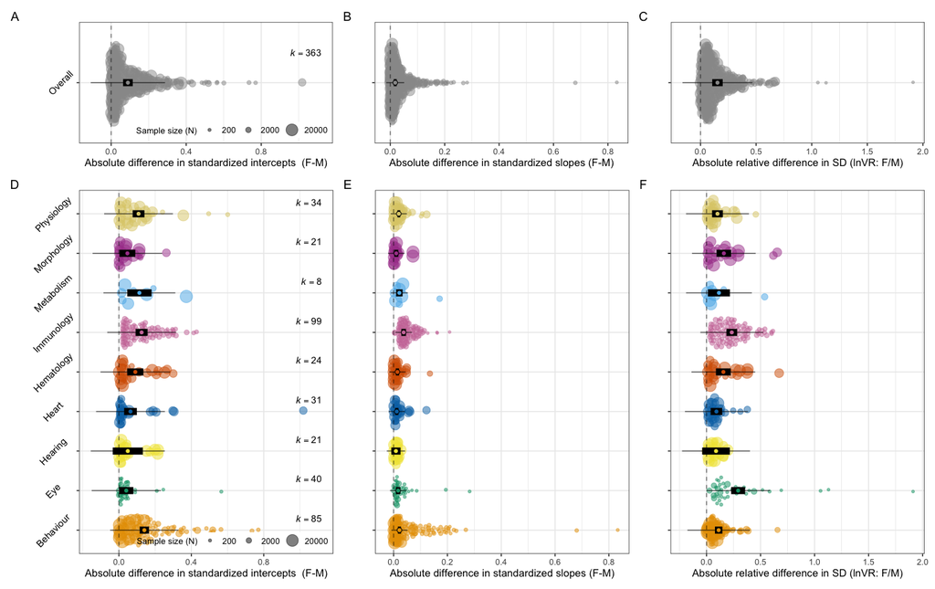

```r
# colour-blind freindly colour
cbpl <- c("#E69F00", "#009E73", "#F0E442", "#0072B2", "#D55E00", "#CC79A7", "#56B4E9",
    "#AA4499", "#DDCC77")

point.size = 2
branch.size = 3.5

# intercept meta-analysis
p1 <- orchard_plot2(modelia, mod = "Int", xlab = "Absolute difference in standardized intercepts  (F-M)",
    angle = 45, point.size = point.size, N = dat$total_n, legend.on = TRUE, branch.size = branch.size,
    ) + scale_y_discrete(labels = "Overall") + scale_fill_manual(values = "#999999") +
    scale_colour_manual(values = "#999999")  #+
# xlim(c(-0.5, 1.5))

# intercept meta-regression
p2 <- orchard_plot2(model1a, mod = "Category", xlab = "Absolute difference in standardized intercepts  (F-M)",
    angle = 45, point.size = point.size, N = dat$total_n, legend.on = TRUE, branch.size = branch.size,
    ) + scale_fill_manual(values = cbpl) + scale_colour_manual(values = cbpl)  #+
# xlim(c(-0.5, 1.5))

# slope meta-analysis
p3 <- orchard_plot2(modelsa, mod = "Int", xlab = "Absolute difference in standardized slopes (F-M)",
    angle = 45, point.size = point.size, k = F, N = dat$total_n, legend.on = FALSE,
    branch.size = branch.size, ) + scale_y_discrete(labels = "") + scale_fill_manual(values = "#999999") +
    scale_colour_manual(values = "#999999")  #+
# xlim(c(-1.5, 10))

# slope meta-regression
p4 <- orchard_plot2(model2a, mod = "Category", xlab = "Absolute difference in standardized slopes (F-M)",
    angle = 45, cb = F, point.size = point.size, k = F, N = dat$total_n, legend.on = FALSE,
    branch.size = branch.size, ) + scale_y_discrete(labels = rep("", 9)) + scale_fill_manual(values = cbpl) +
    scale_colour_manual(values = cbpl)  #+
# xlim(c(-1.5, 10))

# SD meta-analysis
p5 <- orchard_plot2(modelsda, mod = "Category", xlab = "Absolute relative difference in SD (lnVR: F/M)",
    angle = 45, point.size = point.size, k = F, N = dat$total_n, legend.on = FALSE,
    branch.size = branch.size, ) + scale_y_discrete(labels = "") + scale_fill_manual(values = "#999999") +
    scale_colour_manual(values = "#999999")  #+
# xlim(c(-0.2, 1.9))

# SD meta-regression
p6 <- orchard_plot2(model3a, mod = "Category", xlab = "Absolute relative difference in SD (lnVR: F/M)",
    angle = 45, cb = F, point.size = point.size, k = F, N = dat$total_n, legend.on = FALSE,
    branch.size = branch.size, ) + scale_y_discrete(labels = rep("", 9)) + scale_fill_manual(values = cbpl) +
    scale_colour_manual(values = cbpl)  #+
# xlim(c(-0.2, 1.9))


# putting it together
(p1 | p3 | p5)/(p2 | p4 | p6) + plot_layout(heights = c(1, 3)) + plot_annotation(tag_levels = "A")
```

**Fig. 3** Orchard plots illustrating results of multilevel meta-analyses (see the main text)